# Statistical Computing

School of Economics and Management  
Beihang University  
http://yanfei.site

## Optimisation in Business

Many problems in business require something to be minimized or maximized.

- Maximizing Revenue
- Minimizing Costs
- Minimizing Delivery Time
- Maximizing Financial Returns

## Optimisation in Statistics

- Maximum Likelihood
- Least Squares
- Method of Moments
- Posterior Mode

## Optimisation

- Suppose we want to find a minimum or maximum of a function \(f(x)\).
- Sometimes \(f(x)\) will be very complicated.
- Are there computer algorithms that can help?
- Yes!

## Newton-Raphson Method

- Newton-Raphson is an iterative method that begins with an initial guess of the root.
- The method uses the derivative of the function \(f^{'}(x)\) as well as the original function \(f(x)\).
- When successful, it converges (usually) rapidly, but may fail as any other root-finding algorithm.

## Newton-Raphson Method

The method tries to solve an equation in the form of \(f(x) = 0\) through the iterative procedure: \[x_{n+1} = x_n - \frac{f(x_n)}{f^{'}(x_n)}.\]

Please think about **Taylor expansion**.

## Geometric interpretation

[figure not shown]

## Stopping Rule

- With each step the algorithm should get closer to the root.
- However, it can run for a long time without reaching the exact root.
- There must be a stopping rule otherwise the program could run forever.
- Let \(\epsilon\) be an extremely small number e.g. \(1 \times 10^{-10}\) called the **tolerance level**.
- If \(|f(x^{*})| < \epsilon\) then the solution is close enough and there is a root at \(x^{*}\).

## Example

- Now find the root of \(f(x) = x^2 - 5\) using Newton method by hand.
- Tell about its geometric interpretation.

## Newton-Raphson Method

1. Select an initial guess \(x_0\), and set \(n = 0\).
2. Set \(x_{n+1} = x_n - \frac{f(x_n)}{f^{'}(x_n)}\).
3. Evaluate \(|f(x_{n+1})|\).
   1. If \(|f(x_{n+1})| < \epsilon\), then stop;
   2. Otherwise set \(n=n+1\) and go back to step 2.

## Lab Session 5

1. Write R code to find the root of \(x^2 = 5\).
2. Now use your Newton-Raphson code to find the root of \(f(x) = \sqrt{|x|}\). Try initial value 0.25.
3. Now use your Newton-Raphson code to find the root of \(x e^{-x^2} = 0.4(e^x + 1)^{-1} + 0.2\). Try initial values 0.5 and 0.6.

What did you learn from mistakes?

## You can use `D()`

```r
newton.raphson <- function(f, init.value, df = NULL, tol = 1e-5, maxiter = 1000) {
  if (is.null(df)) {
    df <- D(f, 'x')
  }
  niter <- 0
  diff <- tol + 1
  x <- init.value
  while (diff >= tol && niter <= maxiter) {
    niter <- niter + 1
    fx <- eval(f)
    dfx <- eval(df)
    if (dfx == 0) {
      warning("Slope is zero: no further improvement possible.")
      break
    }
    diff <- -fx/dfx
    x <- x + diff
    diff <- abs(diff)
  }
  if (niter > maxiter) {
    warning("Maximum number of iterations 'maxiter' was reached.")
  }
  return(list(root = x, f.root = fx, niter = niter, estim.prec = diff))
}
```

## You can also use `deriv()`

```r
newton.raphson <- function(ftn, x0, tol = 1e-9, max.iter = 100) {
  # Newton_Raphson algorithm for solving ftn(x)[1] == 0
  # we assume that ftn is a function of a single variable that returns
  # the function value and the first derivative as a vector of length 2
  #
  # x0 is the initial guess at the root
  # the algorithm terminates when the function value is within distance
  # tol of 0, or the number of iterations exceeds max.iter

  # initialise
  x <- x0
  fx <- ftn(x)
  iter <-  0

  # continue iterating until stopping conditions are met
  while ((abs(fx[1]) > tol) && (iter < max.iter)) {
    x <- x - fx[1]/fx[2]
    fx <- ftn(x)
    iter <-  iter + 1
    cat("At iteration", iter, "value of x is:", x, "\n")
  }

  # output depends on success of algorithm
  if (abs(fx[1]) > tol) {
    cat("Algorithm failed to converge\n")
    return(NULL)
  } else {
    cat("Algorithm converged\n")
    return(x)
  }
}

f <- expression(x^2 - 5)
df <- deriv(f, 'x', func = TRUE)
ftn <- function(x){
  dfx <- df(x)
  f <- dfx[1]
  gradf <- attr(dfx, 'gradient')[1,]
  return(c(f, gradf))
}

newton.raphson(ftn, 1)
```

[output not shown]

## Other Examples

Now try these functions:

1. \(f(x) = x^3 - 2x^2 - 11x + 12\), try starting values 2.35287527 and 2.35284172.
2. \(f(x) = 2x^3 + 3x^2 + 5\), try starting values 0.5 and 0.

## Learn from Mistakes

- Newton-Raphson does not always converge.
- For some functions, using some certain starting values leads to a series that converges, while other starting values lead to a series that diverges.
- For other functions different starting values converge to different roots.
- Be careful when choosing the initial value.
- Newton-Raphson doesn’t work if the first derivative is zero.

## Conclusion

- Why did we spend so much time on finding roots of an equation?
- Isn’t this topic meant to be about optimization?
- Can we change the algorithm slightly so that it works for optimization?

## Optimisation

## Finding a Maximum or Minimum

- Suppose we want to find an minimum or maximum of a function \(f(x)\) (think about maximum likelihood estimation).
- Find the derivative \(f^{'}(x)\) and find \(x^{*}\) such that \(f^{'}(x^*) = 0\).
- This is the same as finding a root of the first derivative. We can use the Newton Raphson algorithm on the first derivative.

## Newton Raphson algorithm for finding local maxima or minima

1. Select an initial guess \(x_0\), and set \(n = 0\).
2. Set \(x_{n+1} = x_n - \frac{f^{'}(x_n)}{f^{''}(x_n)}\).
3. Evaluate \(|f^{'}(x_{n+1})|\).
   1. If \(|f^{'}(x_{n+1})| < \epsilon\), then stop;
   2. Otherwise set \(n=n+1\) and go back to step 2.

## Different Stopping Rules

Three stopping rules can be used.

- \(|f^{'}(x_{n+1})| < \epsilon\).
- \(|x_{n} - x_{n-1}| < \epsilon\).
- \(|f(x_{n}) - f(x_{n-1})| < \epsilon\).

## Intuition

- Focus the step size \(-\frac{f'(x)}{f''(x)}\).
- The signs of the derivatives control the direction of the next step.
- The size of the derivatives control the size of the next step.
- Consider the concave function \(f(x)=-x^4\) which has \(f'(x)=-4x^3\) and \(f''(x)=-12x^2\). There is a maximum at \(x^{*}=0\).

## Role of first derivative

[figure not shown]

## Role of first derivative

[figure not shown]

## Role of first derivative

[figure not shown]

## Role of first derivative

- If \(f''(x)\) is negative the function is locally concave, and the search is for a local maximum.
- To the left of this maximum \(f'(x)>0\).
- Therefore \(-\frac{f'(x)}{f''(x)}>0\).
- The next step is to the right.
- The reverse holds if \(f'(x)<0\).
- Large absolute values of \(f'(x)\) imply a steep slope. A big step is needed to get close to the optimum. The reverse hold for small absolute value of \(f'(x)\).

## Role of first derivative

- If \(f''(x)\) is positive the function is locally convex, and the search is for a local minimum.
- To the left of this maximum \(f'(x)<0\).
- Therefore \(-\frac{f'(x)}{f''(x)}>0\).
- The next step is to the right.
- The reverse holds if \(f'(x)>0\).
- Large absolute values of \(f'(x)\) imply a steep slope. A big step is needed to get close to the optimum. The reverse hold for small absolute value of \(f'(x)\).

## Role of second derivative

[figure not shown]

## Role of second derivative

- Together with the sign of the first derivative, the sign of the second derivative controls the direction of the next step.
- A larger second derivative (in absolute value) implies a larger curvature.
- In this case smaller steps are need to stop the algorithm from overshooting.
- The opposite holds for a small second derivative.

## Multidimensional Optimization

## Functions with more than one input

- Most interesting optimization problems involve multiple inputs.
  - In determining the most risk efficient portfolio the return is a function of many weights (one for each asset).
  - In least squares estimation for a linear regression model, the sum of squares is a function of many coefficients (one for each regressor).
- How do we optimize for functions \(f({x})\) where \({x}\) is a vector?

## Derviatives

- Newton's algorithm has a simple update rule based on first and second derivatives.
- What do these derivatives look like when the function is \(y=f({x})\) where \(y\) is a scalar and \(\mathbf{x}\) is a \(d\times 1\) vector?

## First derivative

Simply take the partial derivatives and put them in a vector \[ \frac{\partial y}{\partial{\mathbf{x}}}= \left( \begin{array}{c} \frac{\partial y}{\partial x_1}\\ \frac{\partial y}{\partial x_2}\\ \vdots\\ \frac{\partial y}{\partial x_d} \end{array} \right)\] This is called the gradient vector.

## An example

The function \(y=x_1^2-x_1x_2+x_2^2+e^{x_2}\) has gradient vector

\[\frac{\partial y}{\partial{\mathbf{x}}}=\left(\begin{array}{c} 2x_1-x_2\\ -x_1+2x_2+e^{x_2} \end{array} \right).\]

## Second derivative

Simply take the second order partial derivatives. This will give a matrix \[ \frac{\partial y}{\partial{\mathbf{x}}\partial{\mathbf{x}}'}= \left( \begin{array}{cccc} \frac{\partial^2 y}{\partial x_1^2}&\frac{\partial^2 y}{\partial x_1\partial x_2}&\cdots&\frac{\partial^2 y}{\partial x_1\partial x_d}\\ \frac{\partial^2 y}{\partial x_2\partial x_1}&\frac{\partial^2 y}{\partial x_2^2}&\cdots&\frac{\partial^2 y}{\partial x_2\partial x_d}\\ \vdots&\vdots&\ddots&\vdots\\ \frac{\partial^2 y}{\partial x_d\partial x_1}&\frac{\partial^2 y}{\partial x_d\partial x_2}&\cdots&\frac{\partial^2 y}{\partial x_d^2}\\ \end{array} \right).\]

This is called the Hessian matrix.

## An example

The function \(y=x_1^2-x_1x_2+x_2^2+e^{x_2}\) has Hessian matrix \[\frac{\partial y}{\partial{\mathbf{x}}\partial{ \mathbf{x}}'}=\left(\begin{array}{cc} 2 & -1\\ -1 & 2 + e^{x_2} \end{array} \right) \]

## Newton’s algorithm for multidimensional optimization

We can now generalise the update step in Newton's method: \[ \mathbf{x_{n+1}}=\mathbf{x_n}-\left(\frac{\partial^2 f({ \mathbf{x}})}{\partial {\mathbf{x}}\partial{\mathbf{x}}'}\right)^{-1} \frac{\partial f({\mathbf{x}})}{\partial {\mathbf{x}}}\]

Now write code to minimise \(y=x_1^2-x_1x_2+x_2^2+e^{x_2}\).

## Maximum likelihood Estimate for linear models

Assume you want to make a regression model \[ y_i = \beta_0 + \beta_1x_{i} + \epsilon_i,~\text{where}~\epsilon_i \sim N(0, 1). \]

- How do we estimate the parameters?
- Write down the log likelihood function with respect to the unknown parameters.
- Write down the gradient for the log likelihood function.
- Write down the Hessian for the log likelihood function.
- Use your newton function to obtain the best parameter estimate.

## Optimizing Using Newton's Method

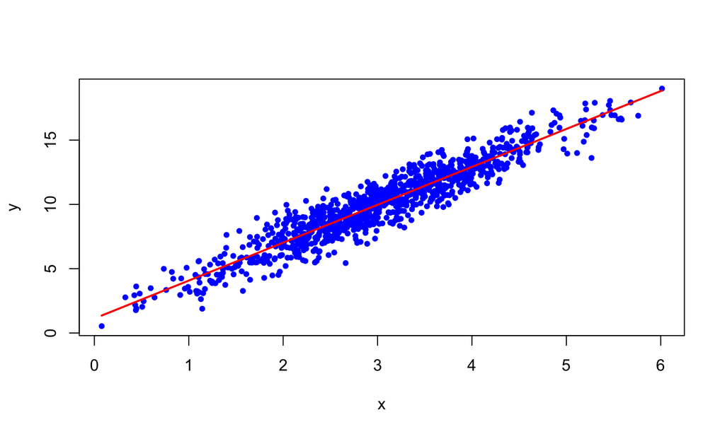

```r
## Generate some data
beta0 <- 1
beta1 <- 3
sigma <- 1
n <- 1000
x <- rnorm(n, 3, 1)
y <- beta0 + x * beta1 + rnorm(n, mean = 0, sd = sigma)
# plot(x, y, col = "blue", pch = 20)

## Make the log normal likelihood function
func = function(beta){
  sum((y-beta[1]-beta[2]*x)^2)
}

grad = function(beta){
  matrix(c(sum(-2*(y-beta[1]-beta[2]*x)),sum(-2*x*(y-beta[1]-beta[2]*x))),2,1)
}

hess = function(beta){
  matrix(c(2*length(x),2*sum(x),2*sum(x),2*sum(x^2)),2,2)
}

## The optimization
source('./RCode/newton.R')
optimOut <- newton(function(beta){list(func(beta), grad(beta), hess(beta))}, c(1.1, 1.3))
beta0Hat <- optimOut[1]
beta1Hat <- optimOut[2]
yHat <- beta0Hat + beta1Hat * x

## Plot
plot(x, y, pch = 20, col = "blue")
points(sort(x), yHat[order(x)], type = "l", col = "red", lwd = 2)
```

## Comparison with OLS

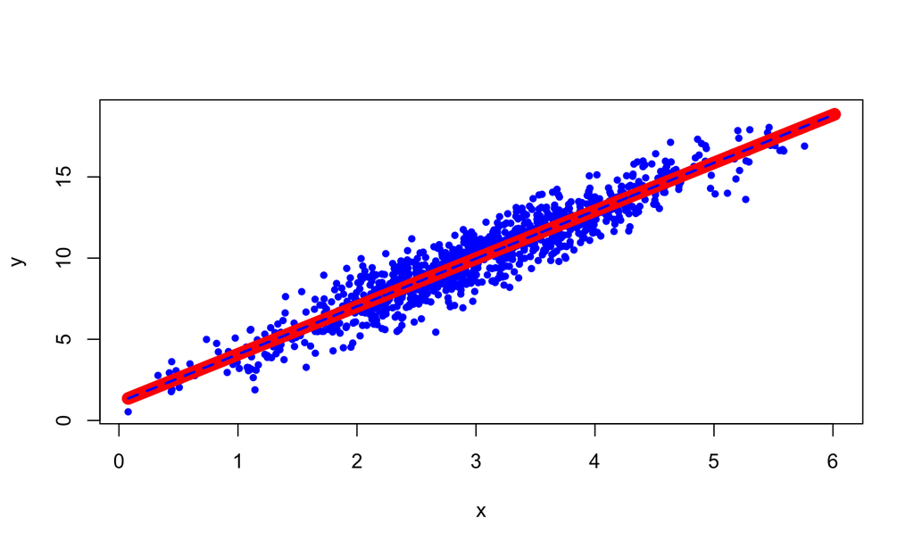

```r
myLM <- lm(y~x)
myLMCoef <- myLM$coefficients
yHatOLS <- myLMCoef[1] + myLMCoef[2] * x
plot(x, y, pch = 20, col = "blue")
points(sort(x), yHat[order(x)], type = "l", col = "red", lwd = 10)
points(sort(x), yHatOLS[order(x)], type = "l",
       col = "blue", lty="dashed", lwd = 2, pch = 20)
```

## Lab Session 7

Use Newton’s method to find the maximum likelihood estimate for the coefficients in a logistic regression. The steps are:

1. Write down likelihood function.
2. Find the gradient and Hessian matrix.
3. Code these up in R.
4. Simulate some data from a logistic regression model and test your code.

## References

Chapters 10 and 12 of the book "Introduction to Scientific Programming and Simulation Using R".